# Community changes modelling

Substantial changes in the hydrological characteristics associated with the construction of structures can have a noticeable impact not only on habitats directly associated with the area of impact, but also on remote habitats. In the practice of ecological monitoring, areas remote from areas of direct anthropogenic influence are often outside the focus of monitoring programs. Therefore, the spatial pattern of changes may be underwstimate. At the same time, the trends detected in the analysis of relatively small areas may provide reliable information to extrapolate these trends to larger areas. This problem can be solved by modeling the behavior of biosystems.

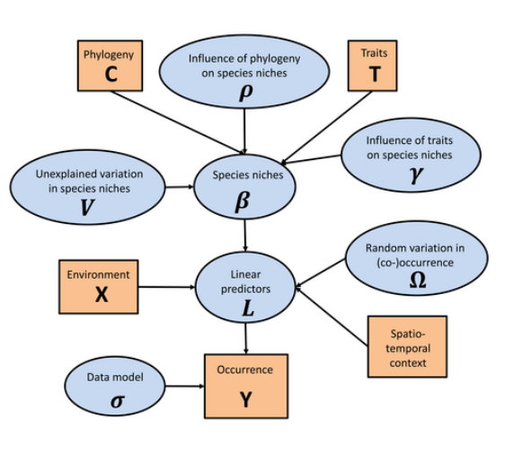

Figure 1. Principal scheme of Joint Species Distribution Modelling (from https://www2.helsinki.fi/en/researchgroups/statistical-ecology/hmsc)

This approach allow to build a model describing the construction of the community under given conditions and then calculate the parameters of the “predicted” community for a new combination of environmental parameters. This approach has been successfully applied to ornithological and geobotanical material (Ovaskainen and Abrego, 2021) and has also been successfully tested in studies of freshwater macrobenthos (Shitikov, Zinchenko and Golovotyuk, 2021) and marine fish communities (Roberts, Halpin and Clark, 2022).

Large-scale building of various engineering constructions is setting up in the Gulf of Ob. This can potentially change the hydrological regime of the entire water area. The most sensitive biological systems under impact are benthic communities. They will experience both direct impact in the sites of constructions and may response in remote areas due to changes in the bottom topography followed by changes in current velocity, new scheme of water mass movements etc.

Hydrophysical consequences of engineering activities changing the bottom relief can be reliably predicted and modelled. This allowed to develop the **INMOM** model which give a possibility to predict the hydrological regime of the Gulf of Ob under two scenarios: “*Native*” (hydrological conditions in the area before engineering) and “*Constructed*” (conditions predicted after constructions builded). The response of benthic communities is not so unambiguously related to hydrophysical conditions and requires special analysis using JSDM. The later being applied to hydrobiological data will enable to answer some questions.

1. How much will the benthic communities change with the implementation of the engineering plans?
2. Which areas of the water area are expected to experience the greatest changes?
3. Which species of hydrobionts are expected to reveal the greatest changes in abundance after engineering plans realization?

The benthic communities were modeled according to the following algorithm.

1. Using the functions from the “Hmsc” package (Tikhonov, Ovaskainen, and Oksanen, 2021), we built a model describing the relationship between the benthos community structure and the hydrological characteristics under “Native” scenario (i.e. without hydrotechnical works). The matrix of species abundances was used as dependent matrix (values were subjected to $ln(N+1)$ transformation). Hydrological parameters predicted by the **INMOM** model, were included as predictors in the model. Three relatively independent (non-collinear) characteristics were used to train the model: salinity, modulus of the zonal current velocity component, and modulus of the meridian current velocity component. The values of the above parameters were predicted by the **INMOM** model for each day of the calendar year. Further, all values were averaged.

When building the model, the relationship with salinity was described by a second degree polynom whereas the relationship with flow velocities was assessed by linear functions.

Since the spatial arangement of sampling stations can potentially cause autocorrelations of response variables, the geographic coordinates of sampling points were included in the model as a random factor.

2. Using the **INMOM**, predictor’s values were obtained for each calendar day accordindly to the “Constructed” scenario, i.e. after engineering works. Analogously to the previous step the matrix of predictor’s values was obtained after averaging of daily data.
3. Using the model coefficients estimated in step 1, a matrix characterizing the “predicted” community under the “Constructed” scenario was constructed.
4. Using the data on species biomass, the mean weights of individuals for each species were calculated. Using this data the total benthic biomass predicted by the model for two regimes were calculated for each station.
5. To assess the degree of difference between the total biomasses of communities under the “Native” and “Constructed” scenario, the value $Dif$ was calculated as follow.

$$Dif = ln(\frac{B_{Constructed}}{B_{Native}})$$

Positive values of this value indicate some increase in total biomass after engineering, whereas negative ones indicate a decrease.

In general, no significant changes in the communities under different hydrological regimes was detected. However, accordingly to model predictions, before engineering, average total biomass is 33.4988 g/m<sup>2</sup>, but after works the total biomass is expected to decrease slightly to 33.1766 g/m<sup>2</sup>. Thus, compared to the “Native” mode, the “Constructed” one is expected to reduce the total biomass by 0.96%.

The proportion of stations in the first group is 24.7%. The proportion of stations predicted to increase biomass is slightly smaller and is 19.6%. Most stations (55.7%) fall into the third group. Thus, there will be no significant changes in most of the area under the two hydrological regimes.

| Station | Lat | Long | $Biomass_{Native}$ | $Biomass_{Constructed}$ | Dif | Proportion of chages (%) | Direction of changes |
| --- | --- | --- | --- | --- | --- | --- | --- |
| O1 | 72.68257 | 73.13191 | 51.4986 | 51.4986 | 0.0000 | 0.00 | Stable |
| O2 | 72.55112 | 74.16659 | 101.4428 | 101.4428 | 0.0000 | 0.00 | Stable |
| O3 | 70.99486 | 73.65296 | 3.8831 | 3.8841 | 0.0003 | 0.03 | Increase |
| O4 | 71.00265 | 73.71557 | 3.4325 | 3.4209 | -0.0034 | -0.34 | Decrease |
| O5 | 70.99105 | 73.70200 | 16.8812 | 16.8569 | -0.0014 | -0.14 | Decrease |
| O6 | 71.00143 | 73.76982 | 37.6302 | 32.5417 | -0.1453 | -13.52 | Decrease |
| O7 | 70.98967 | 73.77115 | 27.1004 | 20.1021 | -0.2987 | -25.82 | Decrease |
| O8 | 71.00752 | 73.79100 | 84.2644 | 56.0395 | -0.4079 | -33.50 | Decrease |
| O9 | 71.00320 | 73.78962 | 13.8865 | 21.8965 | 0.4554 | 57.68 | Increase |
| O10 | 72.55168 | 74.31592 | 10.8730 | 10.5823 | -0.0271 | -2.67 | Decrease |
| O11 | 70.98862 | 73.82909 | 32.8621 | 47.2575 | 0.3633 | 43.81 | Increase |
| O12 | 70.98272 | 73.83549 | 30.7258 | 26.1646 | -0.1607 | -14.84 | Decrease |
| O13 | 72.55214 | 74.46525 | 4.5861 | 4.5861 | 0.0000 | 0.00 | Stable |
| O14 | 71.64894 | 73.32065 | 32.6682 | 32.6682 | 0.0000 | 0.00 | Stable |
| O15 | 72.50690 | 74.32057 | 2.3216 | 2.3216 | 0.0000 | 0.00 | Stable |
| O16 | 72.60083 | 74.31932 | 3.5214 | 3.5214 | 0.0000 | 0.00 | Stable |
| O18 | 72.53534 | 73.94812 | 13.6281 | 13.6281 | 0.0000 | 0.00 | Stable |
| O19 | 72.48098 | 74.18499 | 1.3122 | 1.3122 | 0.0000 | 0.00 | Stable |
| O21 | 72.47078 | 73.77554 | 2.8231 | 2.7483 | -0.0269 | -2.65 | Decrease |
| O22 | 72.70458 | 73.42374 | 16.1075 | 16.0590 | -0.0030 | -0.30 | Decrease |
| O24 | 72.41662 | 74.01209 | 10.8413 | 10.8413 | 0.0000 | 0.00 | Stable |
| O25 | 72.37113 | 73.49883 | 23.7163 | 23.7187 | 0.0001 | 0.01 | Increase |
| O27 | 72.31731 | 73.73490 | 250.4886 | 240.4776 | -0.0408 | -4.00 | Decrease |
| O28 | 72.28294 | 73.27541 | 7.5469 | 7.8406 | 0.0382 | 3.89 | Increase |
| O29 | 72.22938 | 73.51100 | 13.9135 | 13.9109 | -0.0002 | -0.02 | Decrease |
| O30 | 72.19262 | 73.05589 | 38.2482 | 38.2515 | 0.0001 | 0.01 | Increase |
| O31 | 72.16601 | 73.17359 | 33.6461 | 43.8258 | 0.2643 | 30.26 | Increase |
| O32 | 72.72617 | 73.71628 | 4.1339 | 4.1339 | 0.0000 | 0.00 | Stable |
| O33 | 72.13932 | 73.29096 | 3.0580 | 3.0095 | -0.0160 | -1.59 | Decrease |
| O34 | 72.34326 | 72.89751 | 49.0638 | 49.0638 | 0.0000 | 0.00 | Stable |

[output cut: 67 more lines]

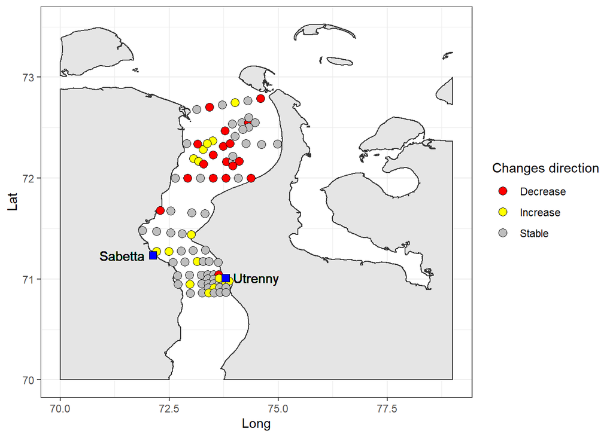

$$GAM: P_{Decrease} = f(Lat, Long) + \varepsilon$$

$f$ - two dimensionsional thin plate smoother,  
$Lat$, $Long$ - geographic coordinates,  
$\varepsilon$ - residuals.

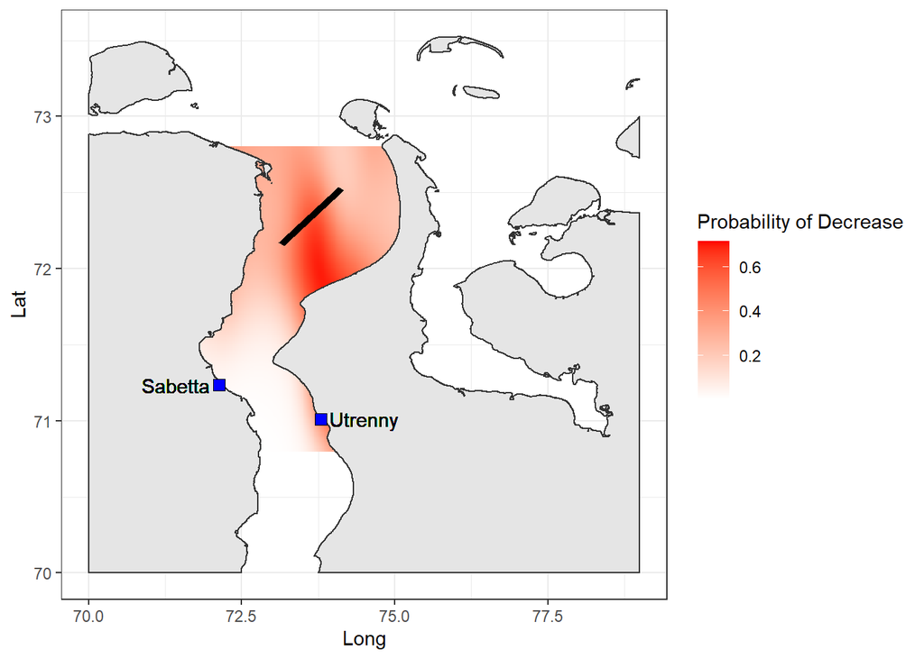

A comparison of the model predicted abundances of individual species allows us to identify forms whose abundance is predicted to increase or decrease. An increase in abundance is expected for the following taxa:Ampharete vega , Halicryptus spinulosus, Sipunculidea gen. sp., Cumacea gen. sp., Diastylis sulcata, Onisimus sp., Portlandia aestuariorum, Oligochaeta. The species expected to decrease their abundance are as follows: Nemertea gen. sp., Limnodrilus hoffmeisteri , Marenzelleria sp., Saduria entomon, Monoporeia affinis, Pontoporeia femorata. It is important to note that species predicted to decrease in abundance include the most abundant crustacean species for the Gulf of Ob (*Saduria entomon*, *Monoporeia affinis*, *Pontoporeia femorata*), which form the basis for feeding benthic fish species.